# Tidy Modeling with R Notes

**JD’s personal study notes on `tidymodels`.**

## 1. Why Tidyness is important for modeling

There are a few existing R packages that provide a unified interface to harmonize these heterogeneous modeling APIs, such as `caret` and `mlr`. The `tidymodels` framework is similar to these in adopting a unification of the function interface, as well as enforcing consistency in the function names and return values. It is different in its opinionated design goals and modeling implementation.

**Examples 1.1**

The `broom::tidy()` function is a tool for standardizing the structure of R objects, which returns many types of R objects in a more usable format.

```r
library(tidyverse)
# the result using map()

corr_res = map(mtcars %>% select(-mpg), cor.test, mtcars$mpg)
head(str(corr_res))
```

[output not shown]

[output cut: 106 more lines]

[output not shown]

```r
corr_res[[1]]
```

```
##
##  Pearson's product-moment correlation
##
## data:  .x[[i]] and mtcars$mpg
## t = -8.9197, df = 30, p-value = 6.113e-10
## alternative hypothesis: true correlation is not equal to 0
## 95 percent confidence interval:
##  -0.9257694 -0.7163171
## sample estimates:
##       cor
## -0.852162
```

Then use `broom::tidy`

```r
library(broom)
tidy(corr_res[[1]])
```

```
## # A tibble: 1 x 8
##   estimate statistic  p.value parameter conf.low conf.high method    alternative
##      <dbl>     <dbl>    <dbl>     <int>    <dbl>     <dbl> <chr>     <chr>
## 1   -0.852     -8.92 6.11e-10        30   -0.926    -0.716 Pearson'… two.sided
```

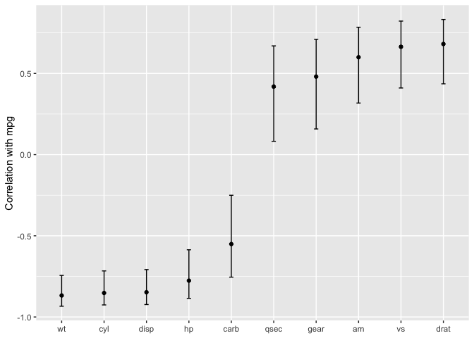

```r
corr_res %>%
  # Convert each to a tidy format; `map_dfr()` stacks the data frames
  map_dfr(tidy, .id = "predictor") %>%
  ggplot(aes(x = fct_reorder(predictor, estimate))) +
  geom_point(aes(y = estimate)) +
  geom_errorbar(aes(ymin = conf.low, ymax = conf.high), width = .1) +
  labs(x = NULL, y = "Correlation with mpg")
```

## 2. Combing Base R models and the `tidyverse`

`dplyr`, `purrr`, `tidyr`

**Example 2.1**

Fit separate models for each category of one variable

Step 1. separate the categories using `group_nest`

```r
data(crickets, package = "modeldata")
split_by_species = crickets  %>% group_nest(species)

split_by_species
```

```
## # A tibble: 2 x 2
##   species                        data
##   <fct>            <list<tibble[,2]>>
## 1 O. exclamationis           [14 × 2]
## 2 O. niveus                  [17 × 2]
```

Step 2. Use `map` to train models

```r
model_by_species <-
  split_by_species %>%
  mutate(model = map(data, ~ lm(rate ~ temp, data = .x)))
model_by_species
```

```
## # A tibble: 2 x 3
##   species                        data model
##   <fct>            <list<tibble[,2]>> <list>
## 1 O. exclamationis           [14 × 2] <lm>
## 2 O. niveus                  [17 × 2] <lm>
```

Step 3. Use `tidy` to convert them to consistent data frame formats

```r
model_by_species %>%
  mutate(coef = map(model, tidy)) %>%
  select(species, coef) %>%
  unnest(cols = c(coef))
```

```
## # A tibble: 4 x 6
##   species          term        estimate std.error statistic  p.value
##   <fct>            <chr>          <dbl>     <dbl>     <dbl>    <dbl>
## 1 O. exclamationis (Intercept)   -11.0      4.77      -2.32 3.90e- 2
## 2 O. exclamationis temp            3.75     0.184     20.4  1.10e-10
## 3 O. niveus        (Intercept)   -15.4      2.35      -6.56 9.07e- 6
## 4 O. niveus        temp            3.52     0.105     33.6  1.57e-15
```

## 3. Dataset Description

The Ames housing data set

```r
data(ames, package = "modeldata")
dim(ames)
```

```
## [1] 2930   74
```

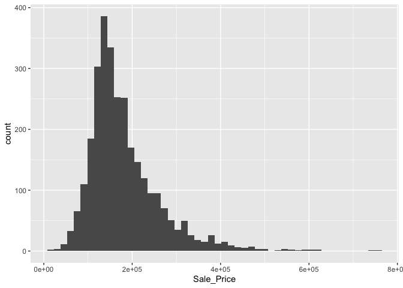

```r
ggplot(ames, aes(x = Sale_Price)) + geom_histogram(bins = 50)
```

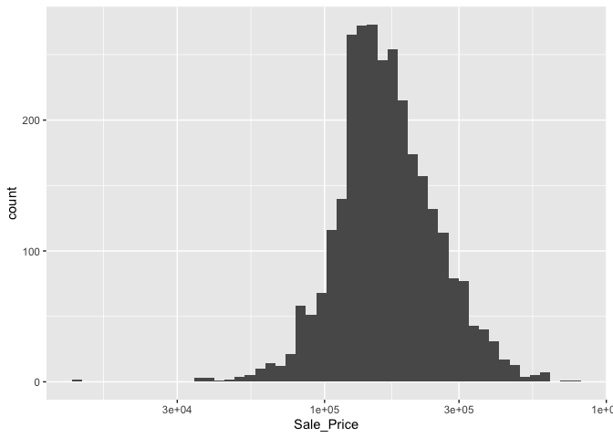

```r
ggplot(ames, aes(x = Sale_Price)) + geom_histogram(bins = 50) + scale_x_log10()
```

```r
ames = ames %>% mutate(Sale_Price = log10(Sale_Price))
```

## 4. Data Spending

Steps to create useful model includes

- parameter estimation
- model selection and tuning
- performance assessment

*data spending*: first consideration when modeling, how should the data be applied to these steps.

### 4.1 Common methods for splitting data

Training set: develop and optimize the model

Test set: final arbiter to determine the efficacy of the model

`inital_split()`

```r
library(rsample)
set.seed(123)

## Get the partitioning information
ames_split = initial_split(ames, prob = 0.8)

ames_train = training(ames_split)
ames_test = testing(ames_split)
```

*Stratified sampling* needs to be used when there is dramatic class imbalance. For regression problems, the outcome data can be artificially binned into quartiles and then stratified sampling conducted four separate times. This is an effective method for keeping the distributions of the outcome similar between the training and test set.

```r
set.seed(123)
ames_split <- initial_split(ames, prob = 0.80, strata = Sale_Price)
ames_train <- training(ames_split)
ames_test  <-  testing(ames_split)
```

## 5. Feature Engineering with `recipes`

Examples of preprocessing to build better features for modeling:

- Correlation between predictors can be reduced via feature extraction or the removal of some predictors
- When some predictors have missing values, they can be imputed using a sub-model
- Models that use variance-type measures may benefit from coercing the distribution of some skewed predictors to be symmetric by estimating a transformation.

### 5.1 Strucutre of a recipe

```r
library(tidymodels)
simple_ames =
  recipe(Sale_Price ~ Neighborhood + Gr_Liv_Area + Year_Built + Bldg_Type,
         data = ames_train) %>%
  step_log(Gr_Liv_Area, base = 10) %>%
  step_dummy(all_nominal())
simple_ames
```

```
## Data Recipe
##
## Inputs:
##
##       role #variables
##    outcome          1
##  predictor          4
##
## Operations:
##
## Log transformation on Gr_Liv_Area
## Dummy variables from all_nominal()
```

1. `recipe` specifies the columns needed for the model
2. `step_log` declares which variable should be log transformed
3. `step_dummy`specifies converting all to dummy. The function `all_nominal` captures the names of any columns that are currently factor or character

*Advantages*

1. Can be recycled across models since not tightly coupled to the modeling function
2. Broader choices for data processing than formulas can offer
3. Compact syntax, e.g. `all_nominal`
4. All procedures captured in one R object

### 5.2 Using recipes

`recipe`: defines the preprocessing,returns a recipe

```r
simple_ames =
  recipe(Sale_Price ~ Neighborhood + Gr_Liv_Area + Year_Built + Bldg_Type,
         data = ames_train) %>%
  step_log(Gr_Liv_Area, base = 10) %>%
  step_dummy(all_nominal())
simple_ames
```

$\bigg\downarrow$

`prep`: calculates the statistics from the training set, returns a recipe $\rightarrow$

```r
simple_ames <- prep(simple_ames, training = ames_train)
simple_ames
```

```
## Data Recipe
##
## Inputs:
##
##       role #variables
##    outcome          1
##  predictor          4
##
## Training data contained 2197 data points and no missing data.
##
## Operations:
##
## Log transformation on Gr_Liv_Area [trained]
## Dummy variables from Neighborhood, Bldg_Type [trained]
```

if set `retain = TRUE` (default), the prepared version of the training set is kept within the recipe. So, for future calcualtion, redundant calcuation can be avoided.

$\bigg\downarrow$

`bake`: applies the preprocessing to datasets, returns a tibble

```r
test_ex = bake(simple_ames, new_data = ames_test)
names(test_ex) %>% head()
```

```
## [1] "Gr_Liv_Area"                "Year_Built"
## [3] "Sale_Price"                 "Neighborhood_College_Creek"
## [5] "Neighborhood_Old_Town"      "Neighborhood_Edwards"
```

To get the preprocessed version of the training

```r
train_ex = bake(simple_ames, new_data = NULL)
```

### 5.3 Encoding qualitatitive data (factors or characters)

`step_unknown`: change missing value to a dedicated factor.

`step_novel`: allot new level for new factor level in new data

`step_other`: analyze the frequencies of the factor levels in the training set and convert infrequently occurring values to a catch-all level of “other”, with a specific threshold that can be specified `step_other(Neighborhood, threshold = 0.01)`

### 5.4 Interaction terms

```r
simple_ames <-
  recipe(Sale_Price ~ Neighborhood + Gr_Liv_Area + Year_Built + Bldg_Type,
         data = ames_train) %>%
  step_log(Gr_Liv_Area, base = 10) %>%
  step_other(Neighborhood, threshold = 0.01) %>%
  step_dummy(all_nominal()) %>%
  # Gr_Liv_Area is on the log scale from a previous step
  step_interact( ~ Gr_Liv_Area:starts_with("Bldg_Type_") )
```

Suppose that, in a recipe, we had not yet made dummy variables for building types. It would be inappropriate to include a factor column in this step.

### 5.5 Skipping steps for new data

Each step function has an option called `skip` that, when set to `TRUE`, will be ignored by the `bake()` function used with a data set argument. In this way, you can isolate the steps that affect the modeling data without causing errors when applied to new samples.

### 5.6 Other exmaples of recipe steps

1. Splines

```r
recipe(Sale_Price ~ Neighborhood + Gr_Liv_Area + Year_Built + Bldg_Type + Latitude,
         data = ames_train) %>%
  step_log(Gr_Liv_Area, base = 10) %>%
  step_other(Neighborhood, threshold = 0.01) %>%
  step_dummy(all_nominal()) %>%
  step_interact( ~ Gr_Liv_Area:starts_with("Bldg_Type_") ) %>%
  step_ns(Latitude, deg_free = 20)
```

2. Feature extraction

E.g. PCA In the Ames data, there are several predictors that measure size of the property, such as the total basement size (Total_Bsmt_SF), size of the first floor (First_Flr_SF), the general living area (Gr_Liv_Area), and so on. PCA might be an option to represent these potentially redundant variables as a smaller feature set. Apart from the general living area, these predictors have the suffix `SF` in their names (for square feet) so a recipe step for PCA might look like

```r
  step_pca(matches("(SF$)|(Gr_Liv)"))
```

There are existing recipe steps for other extraction methods, such as: independent component analysis (ICA), non-negative matrix factorization (NNMF), multidimensional scaling (MDS), uniform manifold approximation and projection (UMAP), and others.

3. Row sampling steps

Downsampling, upsampling, hybrid

`step_downsample()`

This should be only affected for training

### 5.7 How data are used by the recipe

Data are given to recipes at different stages. When calling `recipe(..., data)`, the data set is used to determine the data types of each column so that selectors such as `all_numeric()` can be used. When preparing the data using `prep(recipe, training)`, the data in training are used for all estimation operations, from determining factor levels to computing PCA components and everything in between. It is important to realize that all preprocessing and feature engineering steps only utilize the training data. Otherwise, information leakage can negatively impact the model.

When using `bake(recipe, new_data)`, no quantities are re-estimated using the values in new_data. Take centering and scaling using `step_normalize()` as an example. Using this step, the means and standard deviations from the appropriate columns are determined from the training set; new samples are standardized using these values when `bake()` is invoked.

### 5.8 Using `recipe` with traditional modeling function

Full steps up till now:

*(1) Data preprocessing and model fitting using `lm()`*

```r
ames_rec <-
  recipe(Sale_Price ~ Neighborhood + Gr_Liv_Area + Year_Built + Bldg_Type +
           Latitude + Longitude, data = ames_train) %>%
  step_log(Gr_Liv_Area, base = 10) %>%
  step_other(Neighborhood, threshold = 0.01) %>%
  step_dummy(all_nominal()) %>%
  step_interact( ~ Gr_Liv_Area:starts_with("Bldg_Type_") ) %>%
  step_ns(Latitude, Longitude, deg_free = 20)


ames_rec_prepped <- prep(ames_rec)
ames_train_prepped <- bake(ames_rec_prepped, new_data = NULL)
ames_test_prepped <- bake(ames_rec_prepped, ames_test)

lm_fit <- lm(Sale_Price ~ ., data = ames_train_prepped)
```

*(2) Explore the model summary and coefficients using `broom`*

```r
broom::glance(lm_fit)
```

```
## # A tibble: 1 x 12
##   r.squared adj.r.squared  sigma statistic p.value    df logLik    AIC    BIC
##       <dbl>         <dbl>  <dbl>     <dbl>   <dbl> <dbl>  <dbl>  <dbl>  <dbl>
## 1     0.819         0.813 0.0771      136.       0    71  2550. -4953. -4537.
## # … with 3 more variables: deviance <dbl>, df.residual <int>, nobs <int>
```

```r
tidy(lm_fit)
```

```
## # A tibble: 72 x 5
##    term                            estimate std.error statistic   p.value
##    <chr>                              <dbl>     <dbl>     <dbl>     <dbl>
##  1 (Intercept)                     -0.206    0.299       -0.690 4.90e-  1
##  2 Gr_Liv_Area                      0.643    0.0160      40.2   2.19e-263
##  3 Year_Built                       0.00177  0.000139    12.7   7.23e- 36
##  4 Neighborhood_College_Creek      -0.00903  0.0349      -0.259 7.96e-  1
##  5 Neighborhood_Old_Town           -0.0597   0.0131      -4.54  5.86e-  6
##  6 Neighborhood_Edwards            -0.106    0.0282      -3.75  1.83e-  4
##  7 Neighborhood_Somerset            0.0648   0.0195       3.32  9.22e-  4
##  8 Neighborhood_Northridge_Heights  0.141    0.0288       4.88  1.16e-  6
##  9 Neighborhood_Gilbert             0.0246   0.0232       1.06  2.88e-  1
## 10 Neighborhood_Sawyer             -0.127    0.0270      -4.71  2.65e-  6
## # … with 62 more rows
```

*(3) Prediction*

```r
predict(lm_fit, ames_test_prepped %>% head())
```

```
##        1        2        3        4        5        6
## 5.069175 5.171213 5.284002 5.279534 5.336753 5.298508
```

### 5.9 tidy a recipe

`recipes::tidy()` gives a summary of the recipe steps for an `recipe` object.

```r
tidy(ames_rec_prepped)
```

```
## # A tibble: 5 x 6
##   number operation type     trained skip  id
##    <int> <chr>     <chr>    <lgl>   <lgl> <chr>
## 1      1 step      log      TRUE    FALSE log_iFEDy
## 2      2 step      other    TRUE    FALSE other_IDcSh
## 3      3 step      dummy    TRUE    FALSE dummy_LHrvM
## 4      4 step      interact TRUE    FALSE interact_dMYDN
## 5      5 step      ns       TRUE    FALSE ns_7F7tv
```

### 5.10 Column roles

`recipe()` assigns roles to each of the columns (predictor or outcome). It may be useful to keep that column in the data so that, after predictions are made, problematic results can be investigated in detail. In other words, the column is important but isn’t a predictor or outcome.

### 5.11 Summary

```r
library(tidymodels)
data(ames)
ames <- mutate(ames, Sale_Price = log10(Sale_Price))

set.seed(123)
ames_split <- initial_split(ames, prob = 0.80, strata = Sale_Price)
ames_train <- training(ames_split)
ames_test  <-  testing(ames_split)

ames_rec <-
  recipe(Sale_Price ~ Neighborhood + Gr_Liv_Area + Year_Built + Bldg_Type +
           Latitude + Longitude, data = ames_train) %>%
  step_log(Gr_Liv_Area, base = 10) %>%
  step_other(Neighborhood, threshold = 0.01) %>%
  step_dummy(all_nominal()) %>%
  step_interact( ~ Gr_Liv_Area:starts_with("Bldg_Type_") ) %>%
  step_ns(Latitude, Longitude, deg_free = 20)
```

## 6. Fitting Models with `parsnip`

The `parsnip` package provides a fluent and standardized interface for a variety of different models to avoid the procedures being heterogeneous in either how the data are passed to the model function or in terms of their arguments.

### 6.1 Create a model

For tidymodels, the approach to specifying a model is intended to be more unified:

1. *Specify the type of model based on its mathematical structure* (e.g., linear regression, random forest, K-nearest neighbors, etc).
2. *Specify the engine for fitting the model*. Most often this reflects the software package that should be used.
3. *When required, declare the mode of the model*. The mode reflects the type of prediction outcome. For numeric outcomes, the mode is regression; for qualitative outcomes, it is classification10. If a model can only create one type of model, such as linear regression, the mode is already set.

The `translate()` function can provide details on how parsnip converts the user’s code to the package’s syntax:

```r
library(parsnip)

linear_reg() %>% set_engine("lm") %>% translate()
linear_reg() %>% set_engine("glmnet") %>% translate()
linear_reg() %>% set_engine("stan") %>% translate()
```

[output not shown]

```r
lm_model <-
  linear_reg() %>%
  set_engine("lm")

lm_form_fit <-
  lm_model %>%
  # Recall that Sale_Price has been pre-logged
  fit(Sale_Price ~ Longitude + Latitude, data = ames_train)

lm_xy_fit <-
  lm_model %>%
  fit_xy(
    x = ames_train %>% select(Longitude, Latitude),
    y = ames_train %>% pull(Sale_Price)
    )

lm_form_fit
```

```
## parsnip model object
##
## Fit time:  1ms
##
## Call:
## stats::lm(formula = Sale_Price ~ Longitude + Latitude, data = data)
##
## Coefficients:
## (Intercept)    Longitude     Latitude
##    -311.177       -2.061        2.935
```

```r
lm_xy_fit
```

```
## parsnip model object
##
## Fit time:  2ms
##
## Call:
## stats::lm(formula = ..y ~ ., data = data)
##
## Coefficients:
## (Intercept)    Longitude     Latitude
##    -311.177       -2.061        2.935
```

### 6.2 Use the model results

Use the `purrr::pluck()` function with argument `fit`

```r
library(purrr)
lm_form_fit %>% pluck("fit")
```

```
##
## Call:
## stats::lm(formula = Sale_Price ~ Longitude + Latitude, data = data)
##
## Coefficients:
## (Intercept)    Longitude     Latitude
##    -311.177       -2.061        2.935
```

```r
lm_form_fit %>% pluck("fit") %>% vcov()
```

```
##             (Intercept)    Longitude     Latitude
## (Intercept)  229.229045  1.725841171 -1.608577341
## Longitude      1.725841  0.017955087 -0.001057917
## Latitude      -1.608577 -0.001057917  0.035911248
```